# ss3diags2 user guide

## 10.4 Runs tests and joint residuals

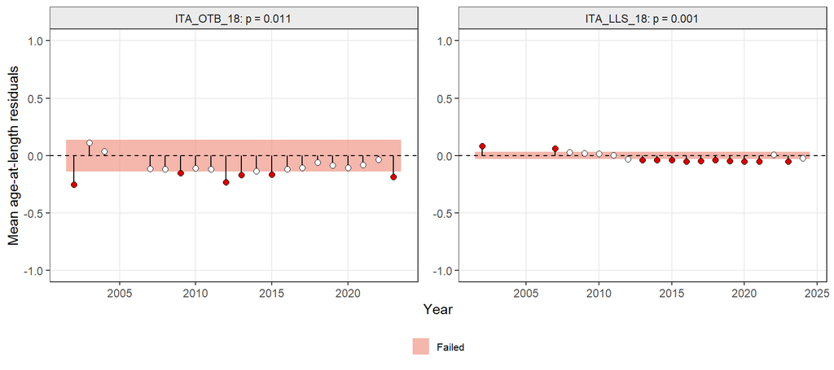

```r
ss3plot_runs(hke, quant = "con")
```

```r
ss3_runs(hke, quant = "len")[, .(index, runs.p, test)]
```

```
#>          index runs.p   test
#>         <char>  <num> <char>
#>  1: ITA_OTB_17  0.243 Passed
#>  2: HRV_OTB_17  0.541 Passed
#>  3: HRV_LLS_17  0.385 Passed
#>  4: HRV_GNS_17  0.541 Passed
#>  5: ITA_OTB_18  0.640 Passed
#>  6: ITA_LLS_18  0.291 Passed
#>  7: MNE_OTB_18  0.083 Passed
#>  8: ALB_OTB_18  0.057 Passed
#>  9: MEDITS_ITA  0.364 Passed
#> 10: MEDITS_HRV  0.739 Passed
#> 11: SOLEMON_17  0.983 Passed
```

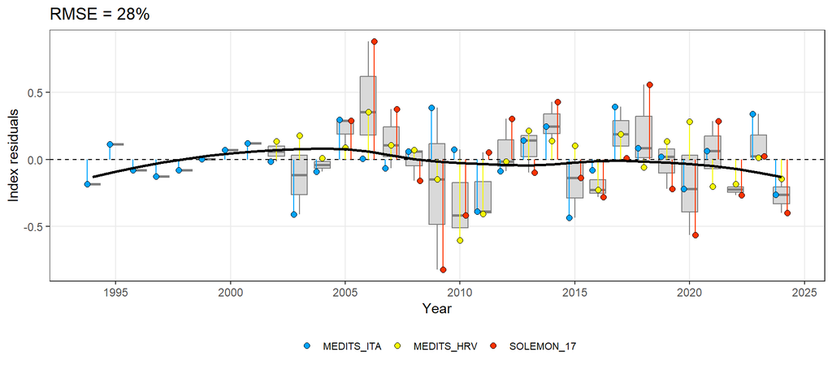

```r
ss3plot_jres(hke)
```

> **Reading the runs tests.** Both conditional age-at-length fleets fail the runs test of the mean age by length (p < 0.05): the mean ages at length run above or below the expected values for several years in a row. Together with the residual plots, this points to time-varying growth or variation in length at age that the model does not capture. The indices and the mean lengths of all fleets pass.

# 11 Stock status: FLStockR and MVLN

`ss3stk()` builds a simplified `FLStockR` (as `FLRef::ss2FLStockR()`): SSB, F, recruitment and catch, with the reference points in `@refpts`. `output = "mle"` gives the maximum likelihood estimates with their standard errors, `output = "iters"` draws from a multivariate lognormal (MVLN) approximation (`ss3mvln()`):

- `method = "joint"` (default) draws SSB, recruitment and F of all years and the reference points from one MVLN with the full correlation matrix of the SS3 derived quantities (Kell et al. 2023; the `ss3om::ssmvln()` approach). Each draw is a coherent trajectory and the reference points have draws.
- `method = "annual"` is the delta-MVLN of `ss3diags::SSdeltaMVLN()` (Walter and Winker 2020; Winker et al. 2019), drawn year by year from the B ratio, F and the F reference.

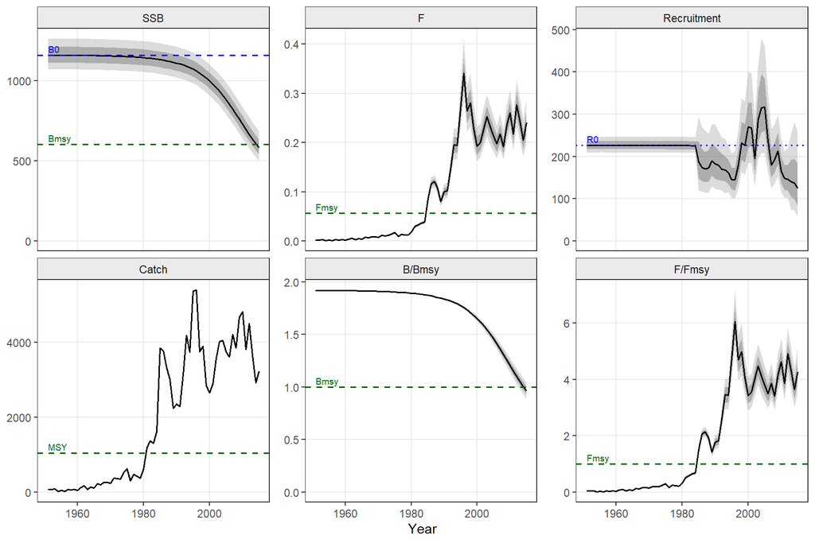

```r
stk <- ss3stk(ss3sma, output = "iters", iters = 1000, fwd = TRUE)
ss3plot_trj(stk)
```

> **SSdeltaMVLN understates the B-F correlation.** For the example models the year-by-year delta-MVLN gives a correlation between B/Bmsy and F/Fmsy in the terminal year of -0.24 for shortfin mako (SS3 covariance: -0.86) and -0.26 for Pacific hake (-0.76), so its Kobe clouds are rounder than the estimated uncertainty. The joint method keeps the estimated correlation; use it for advice.

## 11.1 Which targets: the reference point basis

SS3 can report stock status relative to different benchmarks, set in `starter.ss` (the B ratio denominator and the F report basis) and `forecast.ss` (the benchmarks; the MSY option can be set to the F at a biomass target or at an SPR target). The SS3 labels of the derived quantities also changed between versions. `ss3stk()` works out the basis with the logic of `ss3diags::SSdeltaMVLN()` and `SSsettingsBratioF()`:

1. **B ratio**: the SS3 `Bratio` of the end year is compared with SSB relative to SSB virgin, SSB_MSY and SSB_Btgt (or SSB at F0.1); the closest defines the B target.
2. **F basis**: from `F_std_basis` (SS 3.30) or `F_report_basis` (3.24): absolute F, F/Fmsy, F/F at the B target, or F/F at the SPR target.
3. **F reference**: MSY, unless the MSY benchmark is the B target benchmark (then the F at the B target) or the SPR benchmark (then the SPR F); `Fref =` overrides it.

The status values agree with `SSdeltaMVLN()` for all example models and for the SS3 benchmark options. The labels name the benchmark behind each target rather than the SS3 label, because “MSY” in SS3 output may be a proxy:

| Basis | B target | F target | Catch reference |
| --- | --- | --- | --- |
| MSY benchmark | `Bmsy` | `Fmsy` | `MSY` |
| B ratio relative to B0, target fraction 40% | `B40` | (from the F basis) |  |
| biomass target 40% (or MSY set to F(B40)) | `B40` | `F40` | `Y40` (yield at B40) when MSY is the proxy |
| SPR target 40% (or MSY set to F(SPR40)) | `Bspr40` | `Fspr40` | `Yspr40` when MSY is the proxy |
| F0.1 | `BF0.1` | `F0.1` |  |

The catch reference stays `MSY` when SS3 estimated MSY. The basis is stored in `attr(stk, "basis")`:

```r
str(attr(ss3stk(ss3sma), "basis")[c("B", "F", "C", "bbasis", "fbasis")])
```

```
#> List of 5
#>  $ B     : chr "Bmsy"
#>  $ F     : chr "Fmsy"
#>  $ C     : chr "MSY"
#>  $ bbasis: chr "SSB/SSBMSY"
#>  $ fbasis: chr "(F)/(Fmsy)"
```

```r
str(attr(ss3stk(ss3simple), "basis")[c("B", "F", "C", "bbasis", "fbasis")])
```

```
#> List of 5
#>  $ B     : chr "B40"
#>  $ F     : chr "Fmsy"
#>  $ C     : chr "MSY"
#>  $ bbasis: chr "SSB/SSB0"
#>  $ fbasis: chr "_abs_F"
```

## 11.2 Key quantities as FLQuants

```r
q <- ss3_flqs(stk, c("SSB", "F", "B/Btgt", "F/Ftgt"))
names(q)
```

```
#> [1] "SSB"    "F"      "B/Btgt" "F/Ftgt"
```

# 12 Kobe plots and the timing of F and SSB

> **Critical for advice.** SS3 reports SSB at spawning (typically at the start of the year), and F of year *y* acts during year *y*. The SSB that results from the fishing in year *y* is therefore SSB in year *y + 1*. The usual Kobe plot pairs F(*y*) with SSB(*y*): it shows the biomass the fishery in *y* started from, not the biomass it led to. When F is well above Fmsy, the stock status that follows from the current exploitation can be markedly worse than the plot of F(*y*) against SSB(*y*) suggests. Advice should state which convention is used and, when the two differ, show both.

`ss3plot_kobe(lag = 1)` plots F(*y*) against B/Btgt(*y + 1*). The uncertainty cloud then pairs F(*Y*) with B(*Y + 1*) within each draw, which needs draws linked across years: use `method = "joint"`. Build the stock with `fwd = TRUE` so that SSB at the start of the year after the last assessment year (an SS3 forecast quantity) is available; F is used up to the end year only.

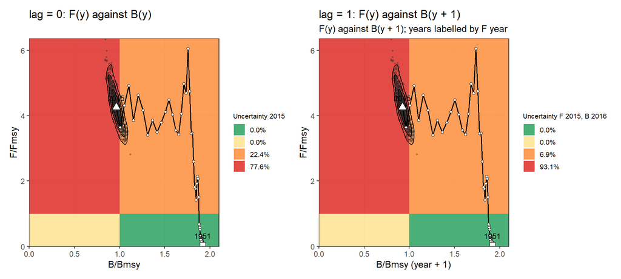

```r
k0 <- ss3plot_kobe(stk) + ggtitle("lag = 0: F(y) against B(y)")
k1 <- ss3plot_kobe(stk, lag = 1) + ggtitle("lag = 1: F(y) against B(y + 1)")
patchwork::wrap_plots(k0, k1)
```

For North Atlantic shortfin mako the probability of being in the red quadrant (overfished and subject to overfishing) in 2015 is about 78% with F(2015) against SSB(2015) and about 93% with F(2015) against SSB(2016).

> **Before using the lagged plot for advice.** SSB(*y + 1*) for the last assessment year is a one-year forecast: it depends on the SS3 forecast settings (`forecast.ss`) and, where recruits mature within a year, on the forecast recruitment. Kell et al. (2023) pair F and SSB both ways in their figures; the convention is not standardised, which is why it must be stated with the advice.

# 13 Production function and equilibrium

`ss3_eqcurve()` extracts the SS3 equilibrium yield curve and `ss3_spm()` fits a Pella-Tomlinson production function to it, as a surplus production model equivalent of the age-structured model (the “production function” of JABBA3), and checks it against the SS3 benchmarks.

```r
sp <- ss3_spm(ss3sma)
sp
```

```
#> Pella-Tomlinson fit to the SS3 equilibrium curve (K free), R2 = 0.99988
#>         r         K         m       MSY      Bmsy     BmsyK      Hmsy
#>    3.8890 1152.0000    2.2700 1035.0000  604.3000    0.5244    1.7130
#>
#> Check against SS3 benchmarks:
#>    quantity       SS3       SPM  rel.diff
#>      <char>     <num>     <num>     <num>
#> 1:      MSY 1041.5400 1035.1364 -0.006148
#> 2:     Bmsy  603.5820  604.3169  0.001218
#> 3:       B0 1158.0100 1152.3628 -0.004877
#> 4:  Bmsy/B0    0.5212    0.5244  0.006124
```

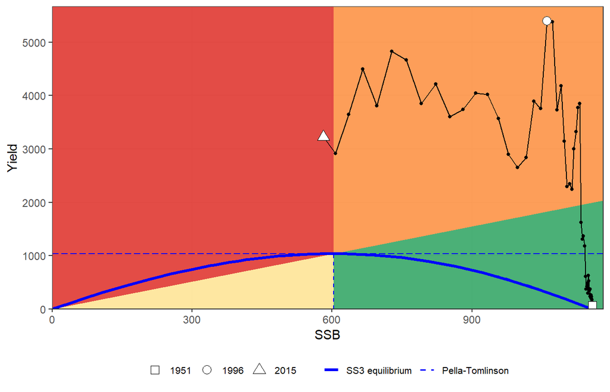

```r
ss3plot_production(ss3stk(ss3sma))
```

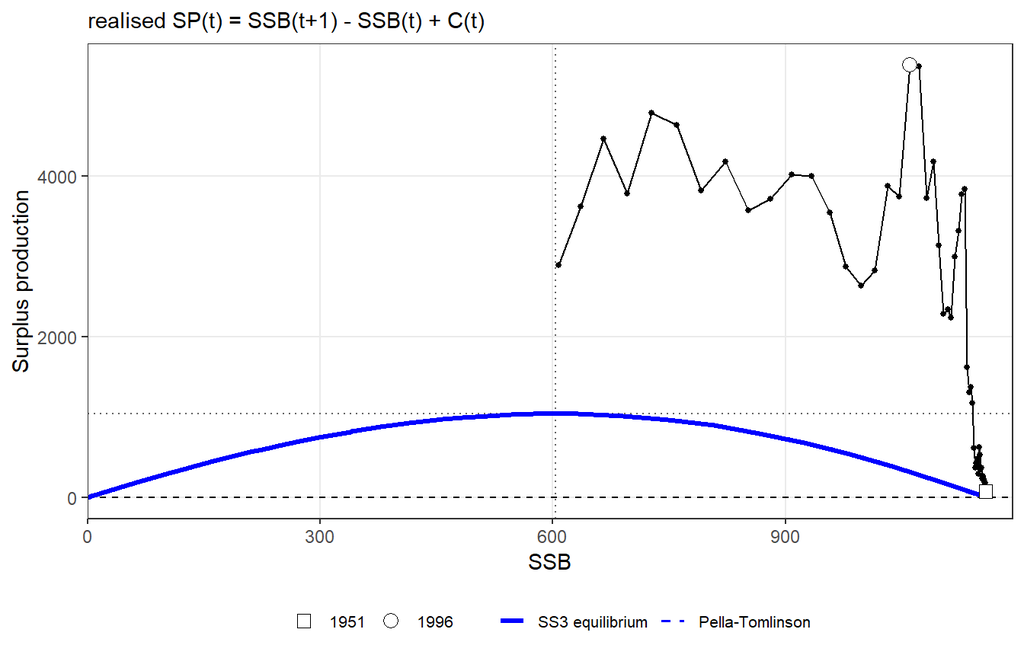

```r
ss3plot_production(ss3stk(ss3sma), type = "dyn")
```

> **Which unfished state?** SS3 holds several: SSB_Virgin (start-year biology), SSB_unfished (benchmark years) and the dynamic B0 of each year. With time-varying weight-at-age or M (empirical `wtatage`, as for Pacific hake) these differ, and the equilibrium table can rest on yet another biology. `ss3_spm()` warns when its fit and the SS3 benchmarks differ by more than 5%.

# 14 Short-term forecasts

Catch advice is based on short-term forecasts: the stock is projected from the assessment through intermediate years (status quo F or a known catch) into the advice year under alternative F (or catch) scenarios. With SS3 the scenarios are run as forecasts in `forecast.ss` (fixed F by fleet and season, scaled from the F basis of the advice to apical F; see the FLRef workflow and `ss3diags::SSnewrun()`), and the runs are read with `r4ss::SSgetoutput()`. ss3diags2 takes it from there: `ss3_fwd()` converts the runs into `FLStockR` objects, `ss3plot_fwd()` plots the scenarios with or without uncertainty, and `ss3_fwdtable()` summarises the fishing opportunities.

The example is the Adriatic hake (GSAs 17-18, reference year 2024) with three F scenarios run in SS3: the advice F (Fadv), status quo F (Fsq) and no fishing (F0), after two intermediate years (2025-2026) at the recent catch. The assessment report used throughout this guide (`hke.37.17-18.rds`) is the Fadv run, so it serves as the reference model, and the scenarios are kept as their `r4ss::SSsummarize()` summary, which holds the derived quantities with their standard errors in a fraction of the size:

```r
fw <- readRDS(system.file("extdata", "hke.37.17-18", "hke.37.17-18_fwd.rds", package = "ss3diags2"))
fw$modelnames
```

```
#> [1] "Fadv" "Fsq"  "F0"
```

> **Not formal advice.** The reference points below are the model’s own estimates (Btgt = SSB at B35%, Ftgt = the corresponding F, Bpa and Blim at 50% and 25% of Btgt); the forecasts illustrate the functions and are not the GFCM advice for this stock.

```r
fs  <- ss3_fwd(fw, Fref = "Btgt", bpa = 0.5, blim = 0.25)            # MLE and SE of each scenario
stk <- ss3stk(hke, Fref = "Btgt", bpa = 0.5, blim = 0.25)             # assessment (reference model)
fs[[1]]@refpts
```

```
#> An object of class "FLPar"
#> params
#>     Ftgt     Btgt      MSY       B0       R0     Blim      Bpa
#> 2.36e-01 9.52e+04 7.57e+03 2.72e+05 1.14e+06 2.38e+04 4.76e+04
#> units:  NA NA NA NA NA NA NA
```

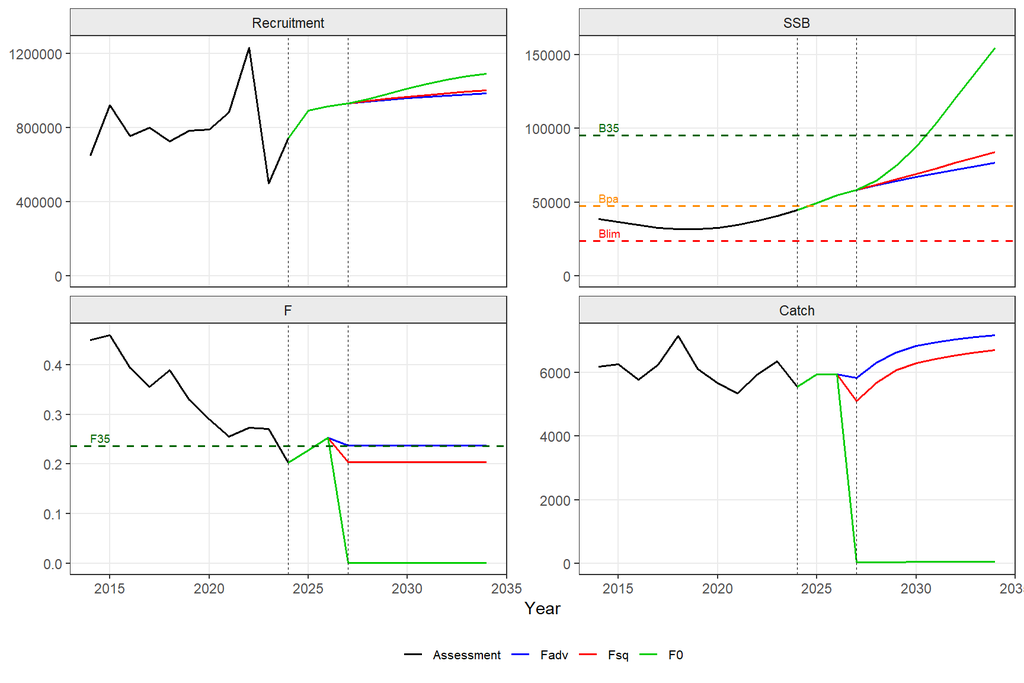

```r
ss3plot_fwd(fs, stk = stk, ci = FALSE)
```

With uncertainty: the assessment from MVLN draws of the reference model, the scenarios from their standard errors:

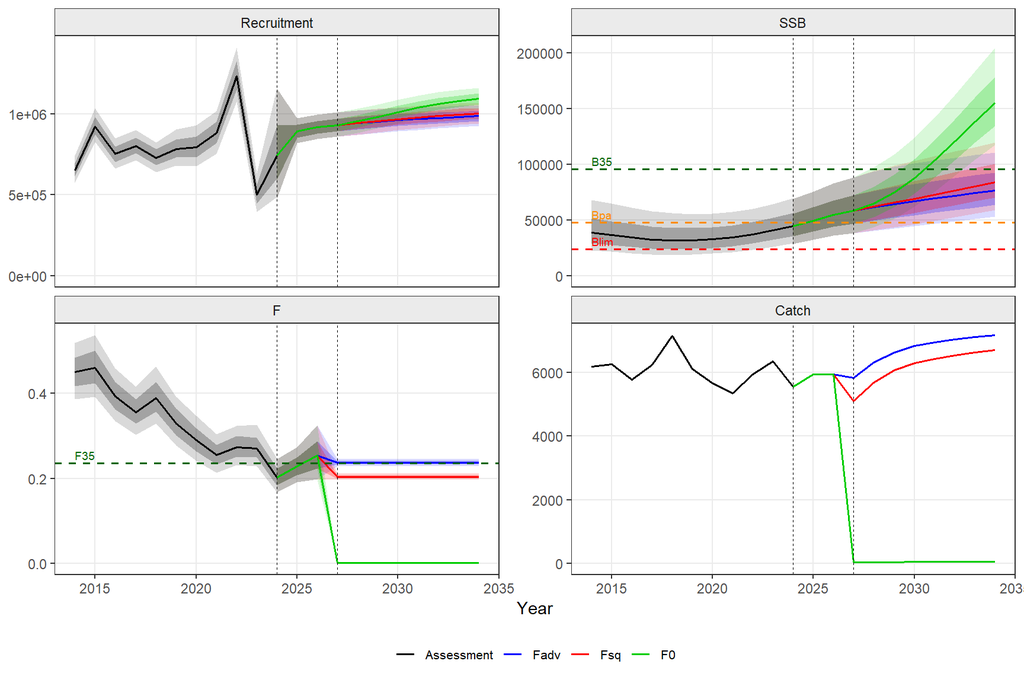

```r
stki <- ss3stk(hke, output = "iters", iters = 1000, Fref = "Btgt", bpa = 0.5, blim = 0.25)
ss3plot_fwd(fs, stk = stki)
```

The fishing opportunities table gives catch and F in the advice year (the first year in which the scenarios differ, 2027), SSB at the start of the next year, its change from the advice year, and the probability of SSB below Blim (lognormal with the SS3 standard error; from the draws when the full reports are used with `ss3_fwd(output = "iters")`):

```r
ss3_fwdtable(fs)
```

```
#>     Basis C_2027 F_2027 SSB_2028 SSB_change P(SSB_2028<Blim)
#>    <char>  <num>  <num>    <num>      <num>            <num>
#> 1:   Fadv 5835.0  0.237    61519        5.6                0
#> 2:    Fsq 5095.7  0.204    61952        6.4                0
#> 3:     F0   27.8  0.001    64904       11.4                0
```

> **Reading the forecast plot.** The black line and bands are the assessment, the coloured lines the scenarios from the end year (2024, first dashed line) on. The second dashed line is the implementation (advice) year (2027); between the lines are the intermediate years (2025-2026), in which all scenarios take the same catch, so they overlap; they separate in the advice year. SSB responds one year later (SSB at the start of 2028 reflects the catch of 2027), which is why the table reports SSB of the year after the advice year. The horizontal lines are the benchmarks (Btgt green, Bpa orange, Blim red; Ftgt green).

# 15 Model ensembles

Advice is increasingly based on an ensemble of assessment models that span structural uncertainty (natural mortality, steepness, growth, data weighting). `ss3_ensemble()` combines the MVLN draws of several SS3 runs, as `ss3diags::SSdeltaMVLN(weight = )` with `SSplotEnsemble(joint = TRUE)`: each model contributes draws in proportion to its weight, and the joint ensemble pools them. Ratios to the targets are computed within each model, with its own reference points, before pooling. `ss3plot_ensemble()` shows the models in colour and the joint ensemble in black, with `ss3plot_trj()`.

The example is the ICES Central Baltic herring (her.27.25-2932, SS3 3.30.22, 1903-2024): three runs that differ in the time series of natural mortality by age (Run2 the highest M, Run3 the lowest), with B30 and F30 as the model-internal benchmarks. The three reports ship in `extdata` (with the covariance reduced to the derived quantities):

```r
her <- readRDS(system.file("extdata", "her.27.25-2932", "her.27.25-2932.rds", package = "ss3diags2"))
names(her)
```

```
#> [1] "Run1" "Run2" "Run3"
```

With equal weights each model contributes the same number of draws:

```r
ens <- ss3_ensemble(her, weights = c(1, 1, 1), iters = 1000)
attr(ens, "weights")
```

```
#>     model    weight iters
#>    <char>     <num> <num>
#> 1:   Run1 0.3333333  1000
#> 2:   Run2 0.3333333  1000
#> 3:   Run3 0.3333333  1000
```

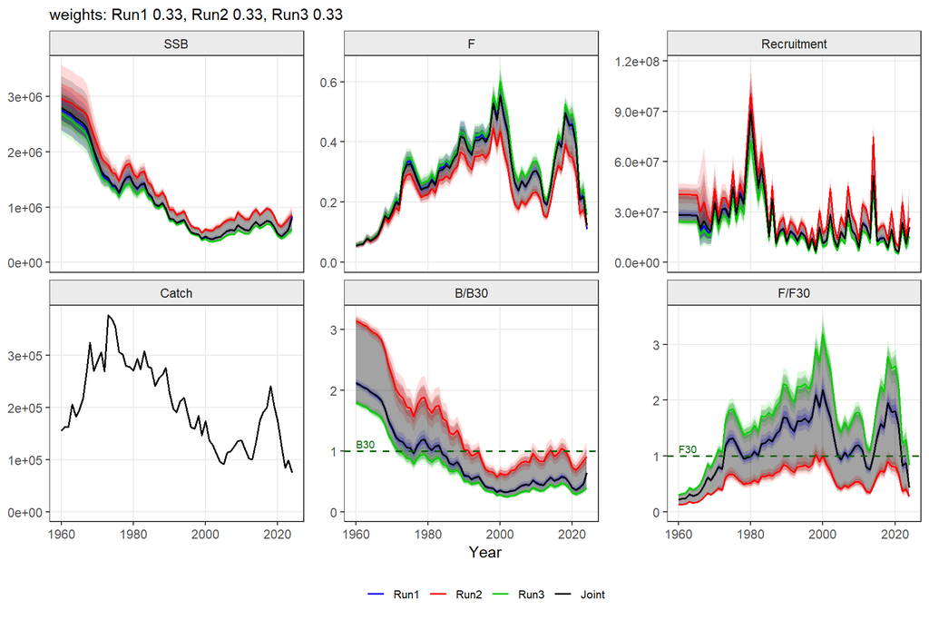

```r
ss3plot_ensemble(ens, start = 1960)
```

With hypothetical weights 1.5, 1 and 0.5 (normalised to 0.5, 0.33 and 0.17) the joint ensemble moves towards Run1 and away from the low-M run:

```r
ensw <- ss3_ensemble(her, weights = c(1.5, 1, 0.5), iters = 1000)
attr(ensw, "weights")
```

```
#>     model    weight iters
#>    <char>     <num> <num>
#> 1:   Run1 0.5000000  1500
#> 2:   Run2 0.3333333  1000
#> 3:   Run3 0.1666667   500
```

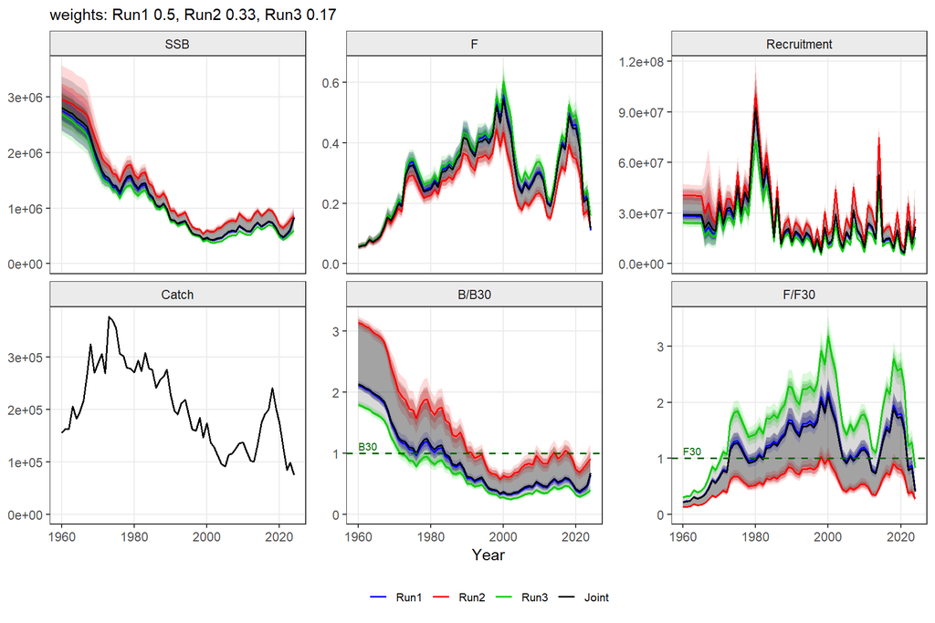

```r
ss3plot_ensemble(ensw, start = 1960)
```

The two joint ensembles on their own, and the Kobe plot of the equally weighted one:

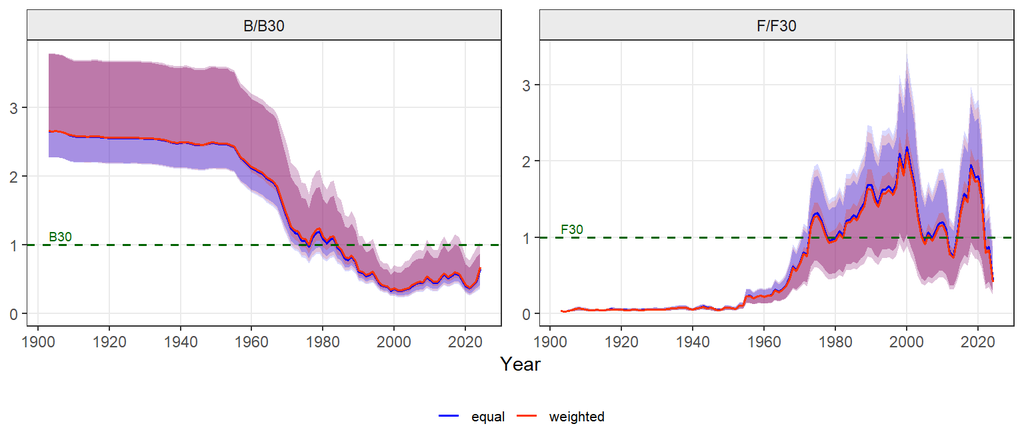

```r
ss3plot_trj(FLCore::FLStocks(equal = ens$Joint, weighted = ensw$Joint), type = c("B/Btgt", "F/Ftgt"))
```

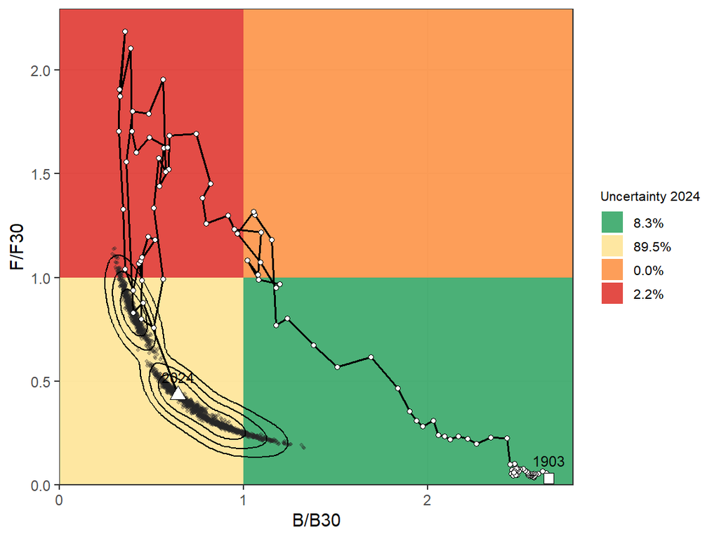

```r
ss3plot_kobe(ens$Joint)
```

> **Weights and years.** Weights are normalised to sum to one; model $i$ contributes `round(iters * n * w_i)` draws. The joint ensemble covers the years common to all models. Models built from `FLStockR` with iterations (`ss3stk(output = "iters")`) are resampled to their number of draws.

> **Reading the ensemble.** The models agree on the trends but differ in scale: with higher M (Run2) the stock is more productive, so biomass is larger relative to B30 and F lower relative to F30; the low-M run (Run3) is the most pessimistic. The joint bands are wider than any single model’s because they include the spread between models (structural uncertainty) as well as the estimation uncertainty within each. Down-weighting Run3 shifts the joint status towards the more optimistic runs, so weights should be justified (diagnostics, plausibility of M), not tuned to the outcome.

# 16 Season-, sex- and area-structured models

The Stock Synthesis assessment of northern shrimp (*Pandalus borealis*) in Skagerrak and the Norwegian Deep (pra.27.3a4a, SS 3.30.22, 1970-2024) uses most of the structure SS3 offers: four seasons (spawning in season 1), two sexes with protandric hermaphroditism (born male, change to female), two areas (1: Skagerrak 3.a, 2: Norwegian Deep 4.a) with time-varying recruitment distribution, six area-specific fleets (Denmark, Norway, Sweden in each area) with retention and discards, and two surveys with sex-specific length compositions. F is reported as Fbar over ages 1-3 (Z - M) and the MSY benchmark is set to the F at B30%. The report and the SS3 input files ship with the package.

```r
dir <- system.file("extdata", "pra.27.3a4a", package = "ss3diags2")
pra <- readRDS(file.path(dir, "pra.27.3a4a.rds"))
ss3_fleets(pra)
```

```
#>    fleet        name   type  area catch_units survey_units ncatch nindex  nlen
#>    <int>      <char> <char> <int>      <char>       <char>  <int>  <int> <int>
#> 1:     1        DK3a  catch     1     biomass      biomass    224      0    93
#> 2:     2        DK4a  catch     2     biomass      biomass    214      0    87
#> 3:     3       NOR3a  catch     1     biomass      biomass    224      0   136
#> 4:     4       NOR4a  catch     2     biomass      biomass    224      0   104
#> 5:     5       SWE3a  catch     1     biomass      biomass    224      0   173
#> 6:     6       SWE4a  catch     2     biomass      biomass    163      0    50
#> 7:     7 NORSURVEY3a survey     1        <NA>      biomass      0     41    41
#> 8:     8 NORSURVEY4a survey     2        <NA>      biomass      0     41    41
#>     nage
#>    <int>
#> 1:     0
#> 2:     0
#> 3:     0
#> 4:     0
#> 5:     0
#> 6:     0
#> 7:     0
#> 8:     0
```

## 16.1 Observations by season, sex and area

Because each fleet fishes in one area, the observations need no area split: the area is a property of the fleet.

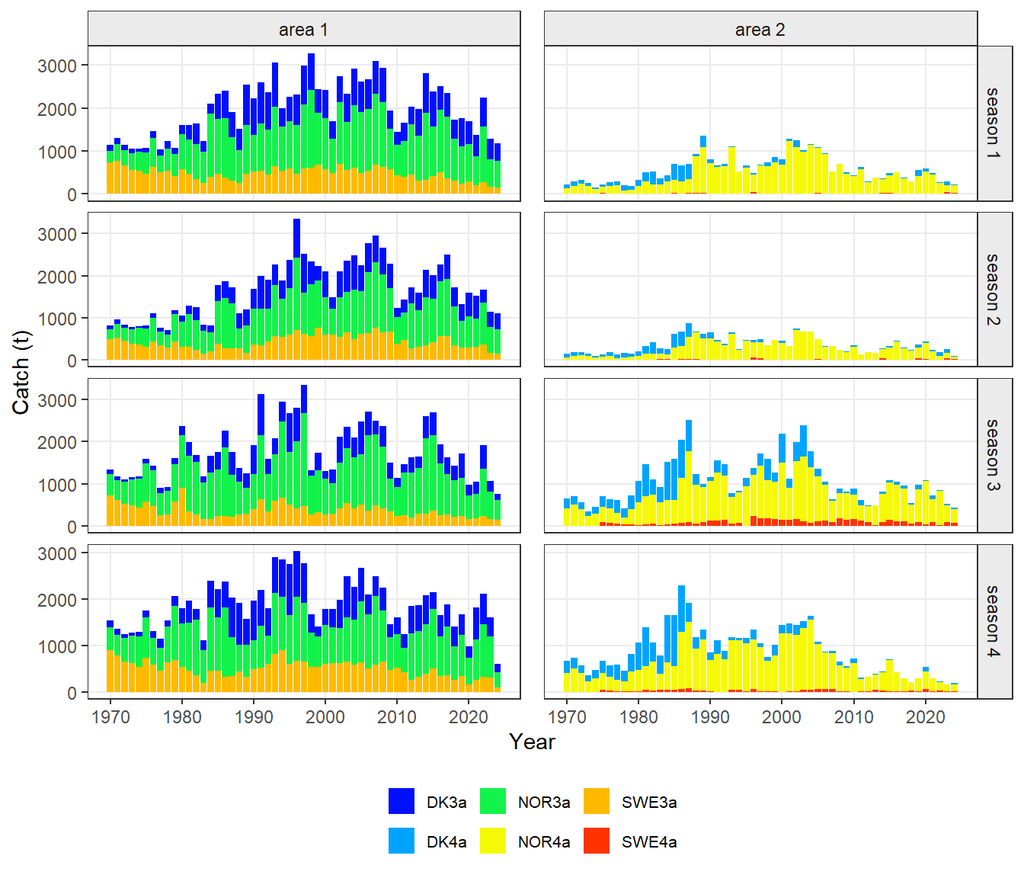

```r
ss3plot_catch(ss3_catch(pra), by = c("season", "area"))
```

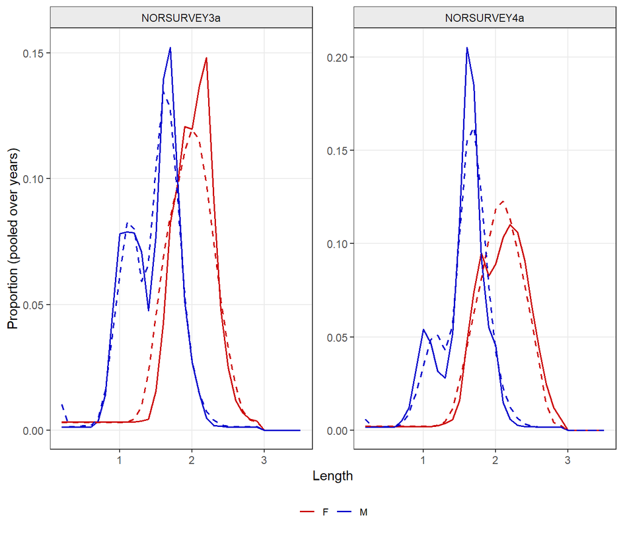

```r
lfp <- ss3_lencomp(pra)
ss3plot_comps(lfp, fit = ss3_lencomp(pra, what = "exp"), fleets = c("NORSURVEY3a", "NORSURVEY4a"), by = "unit")
```

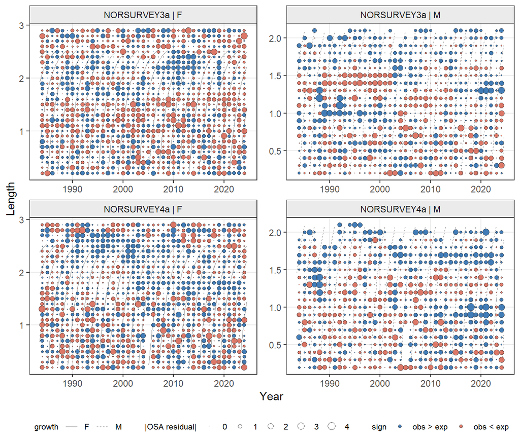

```r
ss3plot_resid(ss3_resid(pra, fleets = c("NORSURVEY3a", "NORSURVEY4a")), lhpar = ss3_lhpar(pra))
```

## 16.2 Selectivity, retention and the stock by area

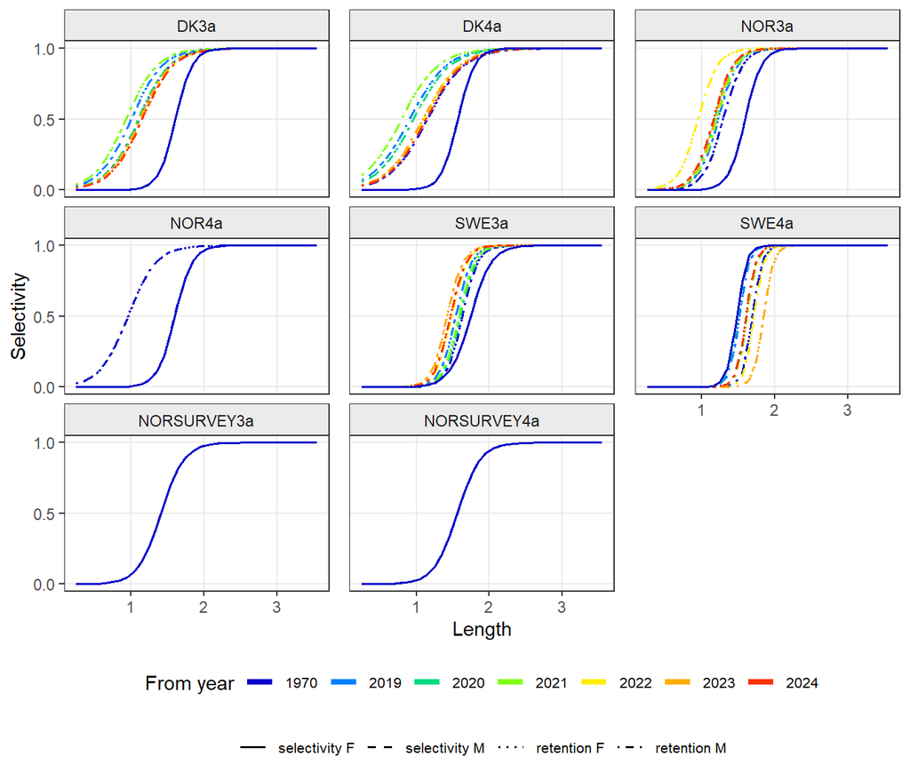

```r
ss3plot_sel(ss3_sel(pra), ret = ss3_sel(pra, "ret"))
```

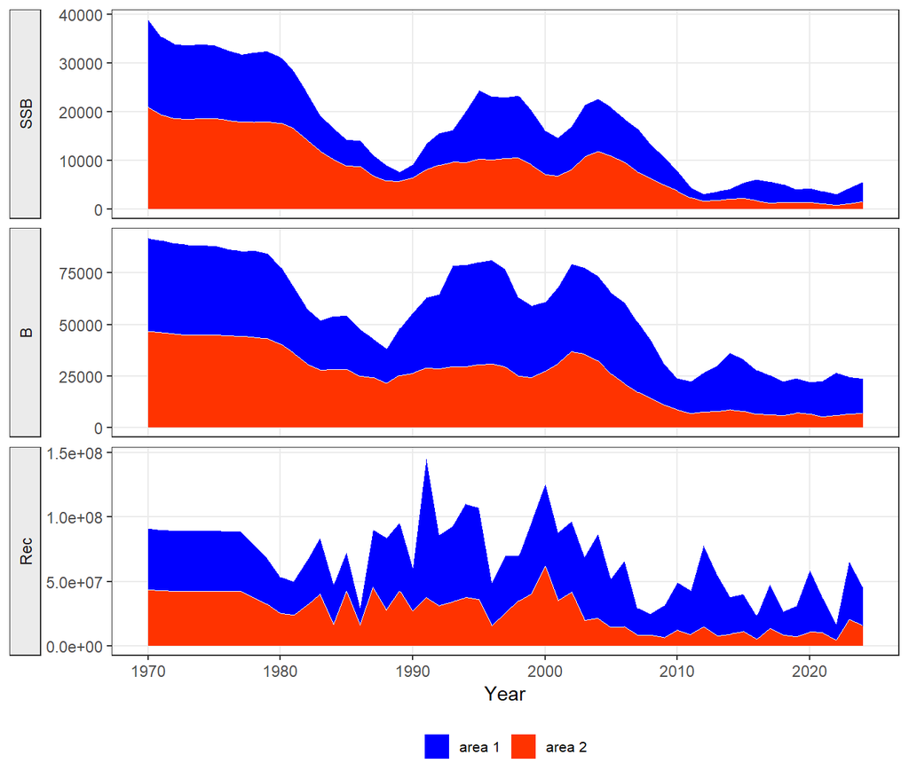

```r
ss3plot_byarea(ss3_byarea(pra))
```

## 16.3 Summary and status

The MSY benchmark is set to the F at B30%, so the targets are `B30` and `F30` and the catch reference is the yield at B30 (`Y30`):

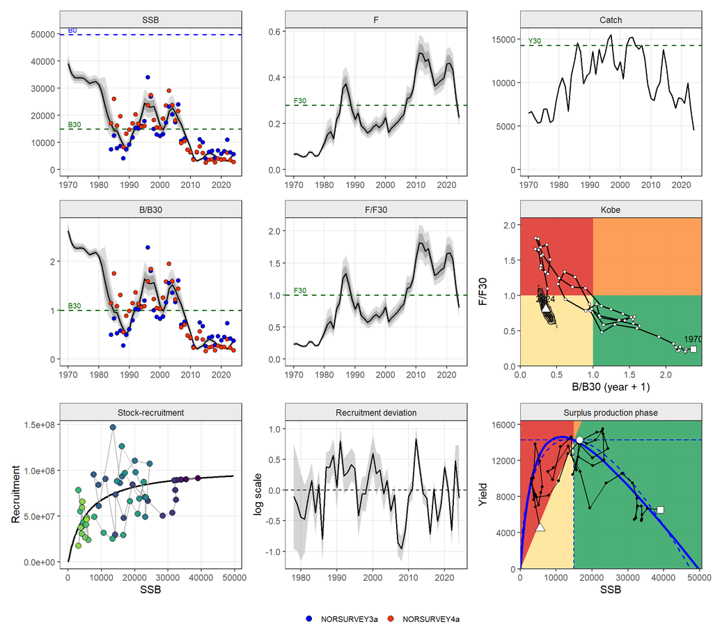

```r
ss3plot(pra, iters = 500, lag = 1)
```

## 16.4 F-at-age, partial F and F by area

`ss3_fa()` returns F-at-age by fleet with the full structure (age, year, unit, season, area); F-at-age is on an annual scale within each season, and `annual = TRUE` sums the seasons weighted by their duration.

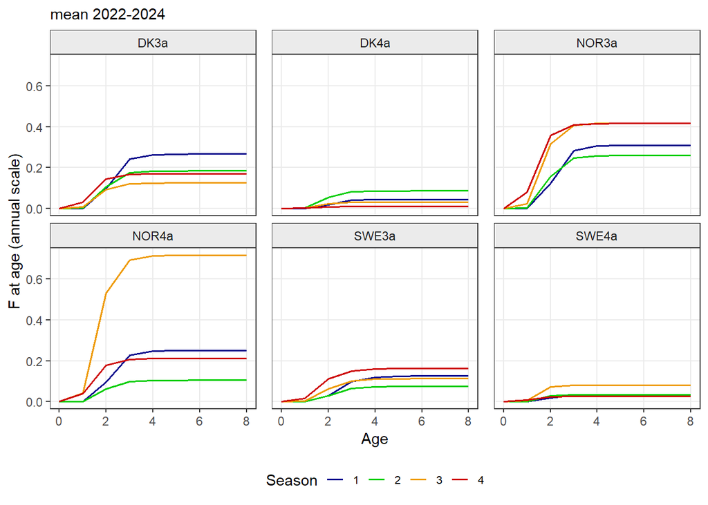

```r
fa <- ss3_fa(pra)
ss3plot_fa(fa)
```

Partial F splits the reported F (Fbar 1-3) among fleets, gears or countries by their catch in numbers over the F ages, so it adds up to F:

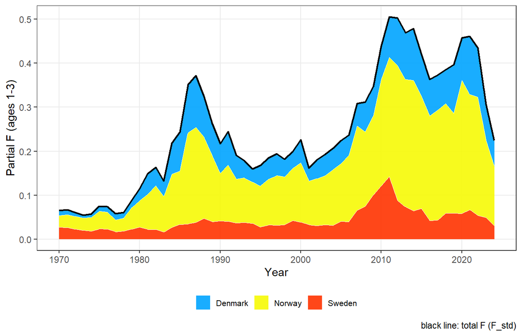

```r
countries <- list(Denmark = c("DK3a", "DK4a"), Norway = c("NOR3a", "NOR4a"), Sweden = c("SWE3a", "SWE4a"))
ss3plot_partialF(ss3_partialF(pra, groups = countries))
```

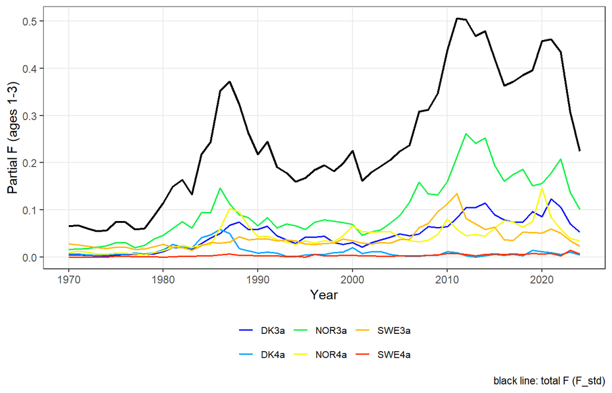

```r
ss3plot_partialF(ss3_partialF(pra), type = "line")
```

> **Two notions of F by area.** The partial F by area (`groups = "area"`, `method = "catch"`) is each area’s share of the stock F and adds up to it. The F experienced by the fish in an area (`method = "fbar"`, the Fbar of the fleets of that area) is the F of a stock by area; F’s of different areas do not add up to the stock F when the stock is spread over the areas.

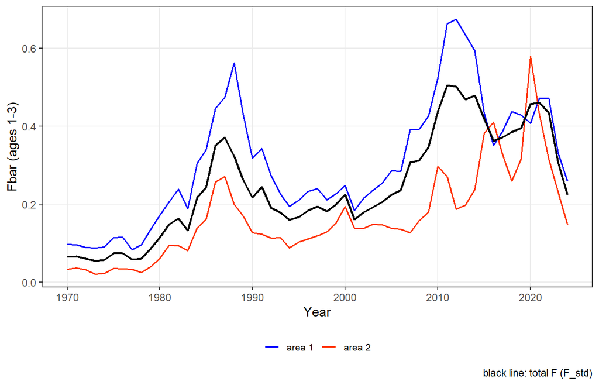

```r
ss3plot_partialF(ss3_partialF(pra, groups = "area", method = "fbar"))
```

## 16.5 Stock by area

`ss3stk(area = TRUE)` returns `FLStocks` with the stock and one `FLStockR` per area: SSB, recruitment and catch by area, and the F experienced in each area. Area reference points are approximations: B0 and R0 are the unfished values of the area, the B target is scaled by the area’s share of B0 and the F target is that of the stock.

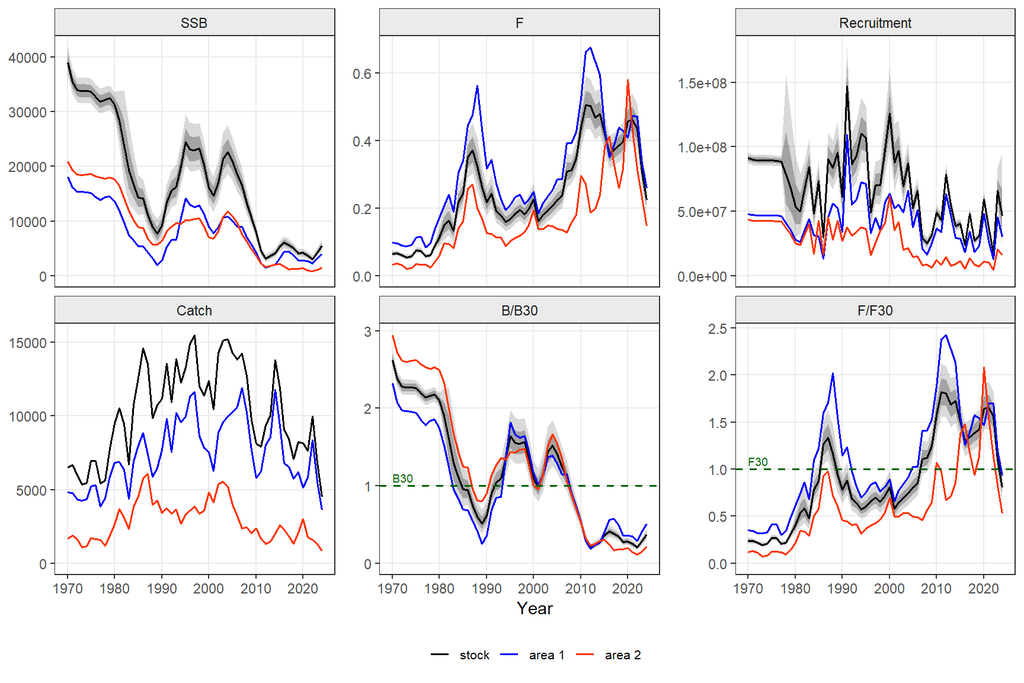

```r
sa <- ss3stk(pra, area = TRUE)
ss3plot_trj(sa)
```

## 16.6 Partial impact of fleets

`ss3_impact()` follows Wang et al. (2009): SSB is projected without fishing and with the fleet groups added one by one, so the impact of a group is the SSB it removes, and all impacts add up to the dynamic B0 minus SSB. It runs on the SS3 report without re-running SS3: annual total mortality from the SS3 numbers at age (seasons, areas and sexes pooled), fishing mortality $Z - M$ split among fleets by their catch at age, the SS3 spawning output at age and recruitment deviations, and each scenario starting from the initial equilibrium under the initial F of its fleets. The run with all fleets reproduces the SS3 SSB and the run without fishing the SS3 dynamic B0:

```r
imp <- ss3_impact(pra, groups = countries)
imp
```

```
#> Partial impact (Wang et al. 2009), cumulative - groups: Denmark, Norway, Sweden
#> max relative difference SS3 vs projected SSB (all fleets): 4.4e-16
#> max relative difference SS3 vs projected dynamic B0 (init = "equilibrium"): 1.6e-05
#> impact in 2024 :
#>      group    impact       prop
#>     <fctr>     <num>      <num>
#> 1: Denmark 15852.480 0.46196805
#> 2:  Norway 16201.220 0.47213092
#> 3:  Sweden  2261.401 0.06590103
```

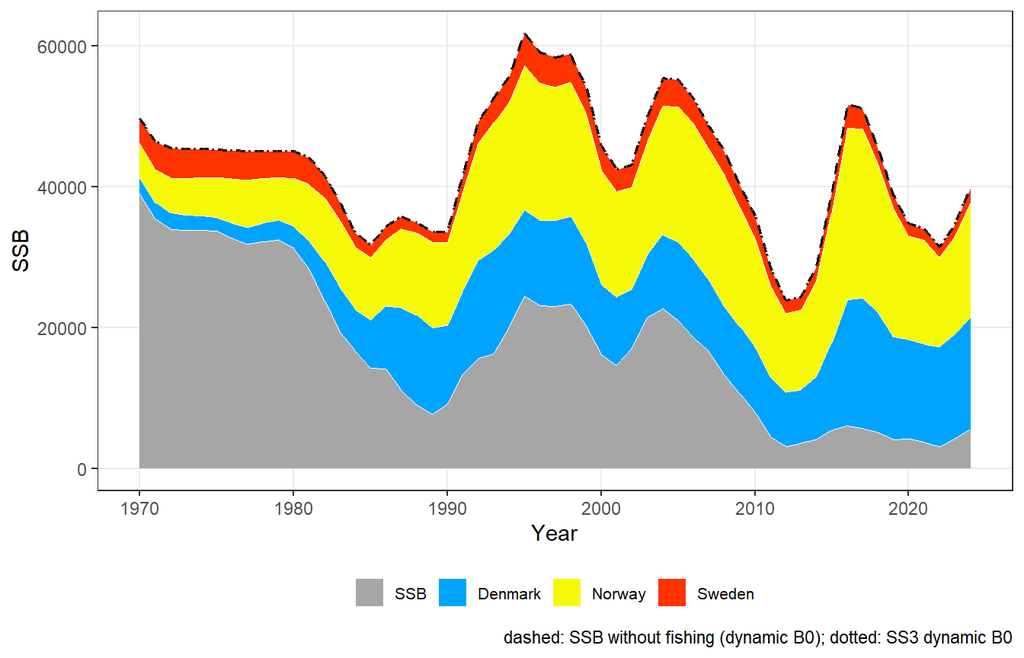

```r
ss3plot_impact(imp)
```

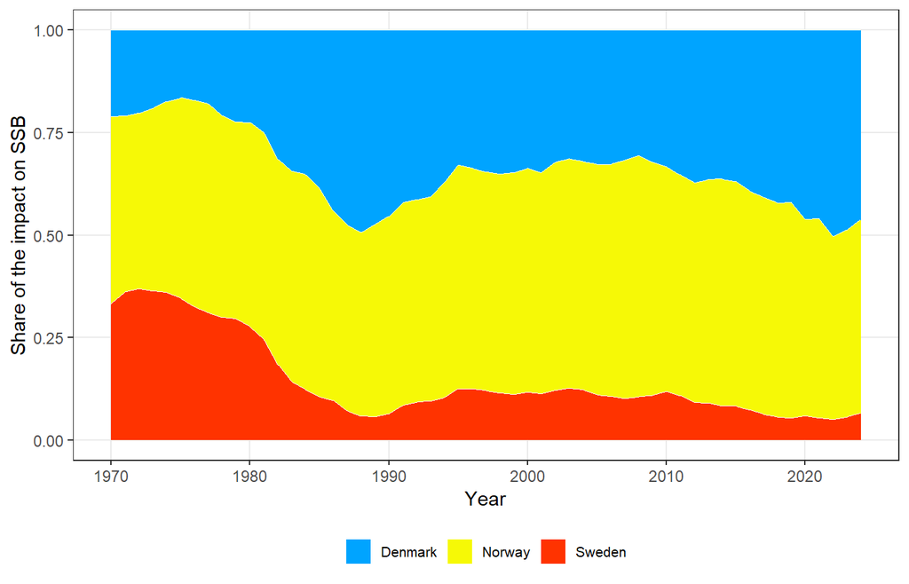

```r
ss3plot_impact(imp, type = "prop")
```

> **Approximations.** When fleets are removed, movement, sex change and the timing within the year stay at their fitted values. The order in which the groups are added matters for the share of each group when the stock-recruit relationship is not flat; `type = "remove"` gives the loss of SSB caused by each group with all others fishing.

# 17 FLR outputs

| Output | Function | Class |
| --- | --- | --- |
| catch, discards by fleet | `ss3_catch()`, `ss3_discards()` | `FLQuants` |
| indices | `ss3_indices()` | `FLIndices` (`FLIndexBiomass`) |
| length, age compositions | `ss3_lencomp()`, `ss3_agecomp()` | `FLQuants` |
| OSA / Pearson residuals | `ss3_resid()` | `FLQuants` |
| life history | `ss3_lhpar()` | `FLPar` (unit by sex) |
| selectivity, retention | `ss3_sel()` | `FLQuants` |
| F-at-age by fleet | `ss3_fa()` | `FLQuants` (age, year, unit, season, area) |
| partial F | `ss3_partialF()` | `FLQuants` (total F as attribute) |
| stock by area | `ss3_byarea()`; `ss3stk(area = TRUE)` | `FLQuants`; `FLStocks` |
| stock status | `ss3stk()` | `FLStockR` (`@refpts`) |
| retrospective peels | `ss3_retro()` | `FLStocks` |
| key quantities | `ss3_flqs()` | `FLQuants` |
| MVLN draws | `ss3mvln()$flqs`, `ss3_flqs(mvln)` | `FLQuants` with iterations |

`long2flq()`, `long2flqs()` and `flqs2long()` convert between the long tables and FLR objects. The stock objects work with FLRef and ggplotFL:

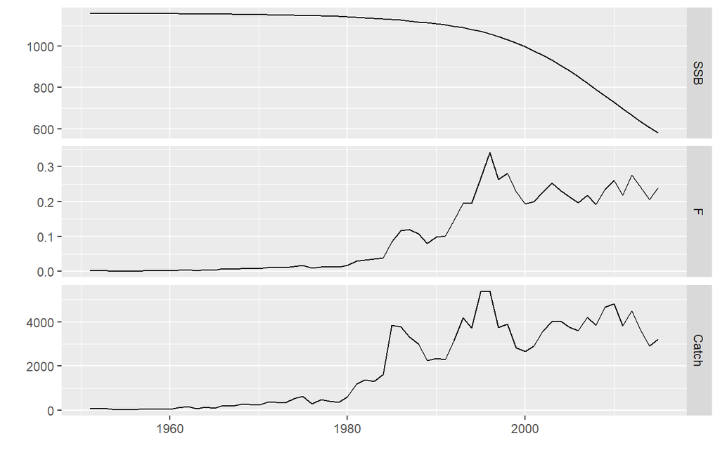

```r
library(ggplotFL)
plot(ss3_flqs(ss3stk(ss3sma), c("SSB", "F", "Catch")))
```

## 17.1 MVLN draws as FLQuants with iterations

`ss3mvln()` returns the draws as `FLQuants` with one iteration per draw (`$flqs`): SSB, F, recruitment, catch, B/Btgt and F/Ftgt, and B/B0 and Catch/MSY where the reference points are reported. `ss3_flqs()` selects quantities from it, and `ss3plot_flqs()` plots the median with 50% and 90% bands, with the ratio panels named after the benchmark and a few single draws (“worms”) if wanted:

```r
mv <- ss3mvln(ss3sma, mc = 1000)              # joint MVLN draws
names(mv$flqs)
```

```
#> [1] "SSB"       "F"         "Rec"       "Catch"     "B/Btgt"    "F/Ftgt"
#> [7] "B/B0"      "Catch/MSY"
```

```r
dim(mv$flqs$SSB)                              # 1000 iterations
```

```
#> [1]    1   65    1    1    1 1000
```

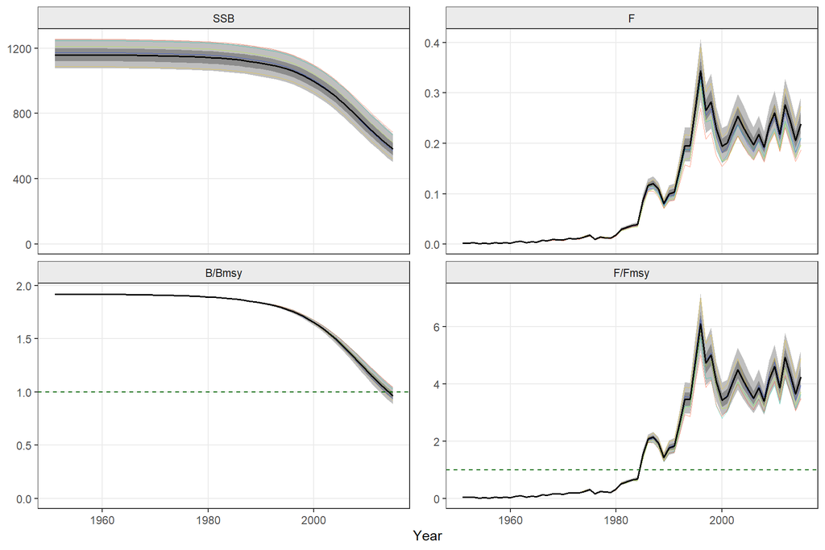

```r
ss3plot_flqs(ss3_flqs(mv, c("SSB", "F", "B/Btgt", "F/Ftgt")), worms = 5)   # 50% and 90% bands, 5 draws
```

The year-by-year delta-MVLN draws (`method = "annual"`) as FLQuants, for Pandalus with the B30 and F30 targets, as single draws only (`ci = FALSE`), each in its own colour (`worm.col = "grey"` for grey) with transparency `alpha` (default 0.5):

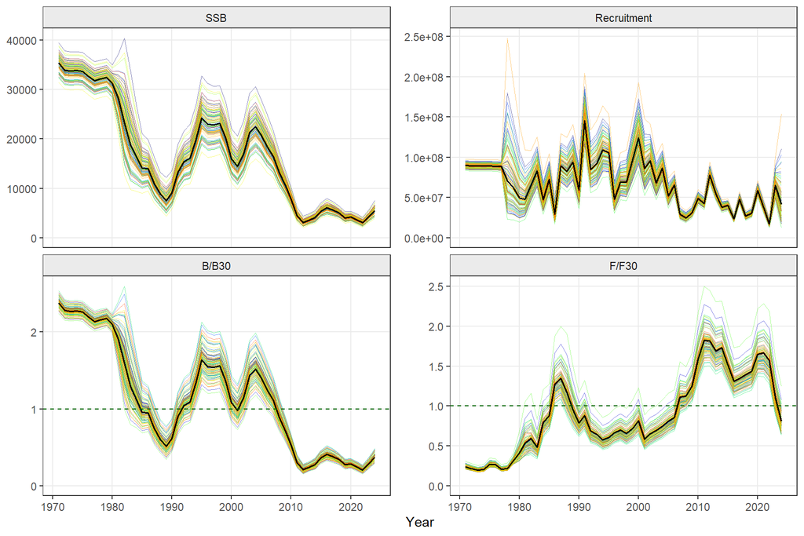

```r
mp <- ss3mvln(pra, mc = 1000, method = "annual")
ss3plot_flqs(ss3_flqs(mp, c("SSB", "Rec", "B/Btgt", "F/Ftgt")), worms = 100, ci = FALSE)
```

The same FLQuants come from the stock with iterations, `ss3_flqs(ss3stk(ss3sma, output = "iters"))`, and work with ggplotFL (`plot(mv$flqs)`).

# 18 Summary of checks and functions

| # | Check | Red flag | Action |
| --- | --- | --- | --- |
| 1 | data (`ss3plot_data`, `ss3plot_nsamp`) | no contrast; conflicting indices; few samples | sensitivity runs; data weighting |
| 2 | fits (`ss3plot_indices`, `ss3plot_comps`) | systematic misfit | conflicts between data; selectivity, catchability |
| 2b | data weighting (`ss3_francis`, `ss3plot_francis`) | Francis weight far from 1 | adjust the variance adjustment; Dirichlet-multinomial |
| 2c | sex ratios (`ss3plot_sexratio`) | observed share of females away from expected | sex-specific growth, M or selectivity |
| 3 | residuals (`ss3plot_resid`, `ss3plot_runs`, `ss3plot_jres`) | failed runs test; residuals outside 3 sigma; RMSE > 30% | time-varying q, selectivity or growth |
| 4 | retrospective (`ss3_mohn`, `ss3plot_retro`) | Mohn’s rho outside -0.15 to 0.20 (short-lived: -0.22 to 0.30) | recent data; time-varying processes |
| 5 | hindcast (`ss3_hindcast`, `ss3plot_hcxval`) | MASE > 1 | index without prediction skill |
| 6 | status (`ss3stk`, `ss3plot_kobe`) | Kobe lag changes the quadrant | state the convention; show both |

## 18.1 Function reference

| Area | Functions |
| --- | --- |
| Example data | `ss3simple`, `ss3sma`, `retro.sma`, `aspm.sma`, `ss3phk`, `retro.phk`, `aspm.phk`, `extdata/pra.27.3a4a` |
| Observations | `ss3_fleets()`, `ss3_catch()`, `ss3_discards()`, `ss3_indices()`, `ss3_lencomp()`, `ss3_agecomp()` |
| Model inputs | `ss2jabba3()`, `ss2flicc()`, `ss3_lhpar()` |
| Observation plots | `ss3plot_sexratio()`, `ss3plot_data()`, `ss3plot_catch()`, `ss3plot_indices()`, `ss3plot_comps()`, `ss3plot_nsamp()`, `ss3plot_growth()`, `ss3plot_ridges()` |
| Residuals | `ss3_resid()` (len, age, conditional age-at-length, size), `ss3plot_resid()`, `ss3plot_caal()`, `ss3_runs()`, `ss3plot_runs()`, `ss3plot_jres()`, `ss3_iresid()` |
| Retro and hindcast | `ss3_retro()`, `ss3_mohn()`, `ss3plot_retro()`, `ss3_hindcast()`, `ss3plot_hcxval()` |
| Data weighting | `ss3_francis()`, `ss3plot_francis()` |
| Forecasts | `ss3_fwd()`, `ss3plot_fwd()`, `ss3_fwdtable()` |
| Ensembles | `ss3_ensemble()`, `ss3plot_ensemble()` |
| OSA residual tests | `ss3_osatest()`, `ss3plot_resid(test = TRUE)` |
| Model scorecard | `ss3_scorecard()`, `ss3plot_scorecard()` |
| Ensemble forecasts and advice | `ss3_fwdensemble()`, `ss3_fwdrisk()`, `ss3_catchopts()`, `ss3_k2sm()` |
| Status | `ss3stk()`, `ss3mvln()`, `ss3_flqs()`, `ss3plot_flqs()`, `ss3plot()`, `ss3plot_trj()`, `ss3plot_kobe()` |
| Production | `ss3_eqcurve()`, `ss3_spm()`, `ss3plot_production()` |
| Structure | `ss3_sel()`, `ss3plot_sel()`, `ss3_byarea()`, `ss3plot_byarea()`, `ss3plot_sr()` |
| F and impact | `ss3_fa()`, `ss3plot_fa()`, `ss3_partialF()`, `ss3plot_partialF()`, `ss3_impact()`, `ss3plot_impact()` |
| Utilities | `long2flq()`, `long2flqs()`, `flqs2long()`, `theme_ss3()`, `ss3cols()` |

# 19 References

Carvalho, F., Winker, H., Courtney, D., Kapur, M., Kell, L., Cardinale, M., Schirripa, M., Kitakado, T., Yemane, D., Piner, K.R., Maunder, M.N., Taylor, I., Wetzel, C.R., Doering, K., Johnson, K.F. and Methot, R.D. (2021). A cookbook for using model diagnostics in integrated stock assessments. *Fisheries Research* 240: 105959.

FAO GFCM (2024). Scientific Advisory Committee on Fisheries (SAC), Working Group on Stock Assessment of Demersal Species (WGSAD): Benchmark session for European hake in the Adriatic Sea. FAO headquarters, Rome, Italy, 11-15 March 2024. Report.

Francis, R.I.C.C. (2011). Data weighting in statistical fisheries stock assessment models. *Canadian Journal of Fisheries and Aquatic Sciences* 68: 1124-1138.

Hurtado-Ferro, F., Szuwalski, C.S., Valero, J.L., Anderson, S.C., Cunningham, C.J., Johnson, K.F., Licandeo, R., McGilliard, C.R., Monnahan, C.C., Muradian, M.L., Ono, K., Vert-Pre, K.A., Whitten, A.R. and Punt, A.E. (2015). Looking in the rear-view mirror: bias and retrospective patterns in integrated, age-structured stock assessment models. *ICES Journal of Marine Science* 72: 99-110.

Kell, L.T., Kimoto, A. and Kitakado, T. (2016). Evaluation of the prediction skill of stock assessment using hindcasting. *Fisheries Research* 183: 119-127.

Kell, L., Rice, J., Courtney, D. and Winker, H. (2023). Approximation of Kobe posteriors from Stock Synthesis for North Atlantic blue shark. *Collective Volume of Scientific Papers ICCAT* 80(4): 837-858 (SCRS/2023/143).

Methot, R.D. and Wetzel, C.R. (2013). Stock synthesis: a biological and statistical framework for fish stock assessment and fishery management. *Fisheries Research* 142: 86-99.

Trijoulet, V., Albertsen, C.M., Kristensen, K., Legault, C.M., Miller, T.J. and Nielsen, A. (2023). Model validation for compositional data in stock assessment models: calculating residuals with correct properties. *Fisheries Research* 257: 106487.

Walter, J. and Winker, H. (2020). Projections to create Kobe 2 Strategy Matrix using the multivariate log-normal approximation for Atlantic yellowfin tuna. *Collective Volume of Scientific Papers ICCAT* 76(6): 725-739 (SCRS/2019/145).

Wang, S.-P., Maunder, M.N., Aires-da-Silva, A. and Bayliff, W.H. (2009). Evaluating fishery impacts: application to bigeye tuna (*Thunnus obesus*) in the eastern Pacific Ocean. *Fisheries Research* 99: 106-111.

Winker, H., Kell, L.T., Fu, D., Sharma, R., Courtney, D., Carvalho, F., Schirripa, M. and Walter, J. (2019). A rapid approach to approximate Kobe posteriors from age-structured assessment models with applications to North Atlantic shortfin mako. ICCAT SCRS/2019/093.